# RF_DDA

### 4. Exploratory Data Analysis [EDA]

```python
# read the CSV file and load it into a DataFrame object
Clean_dataset = pd.read_csv('Clean_dataset.csv')
```

```python
Clean_dataset.shape
```

```
(81284, 15)
```

```python
# Checking the imported dataset
Clean_dataset.info()
```

```
<class 'pandas.core.frame.DataFrame'>
RangeIndex: 81284 entries, 0 to 81283
Data columns (total 15 columns):
 #   Column                  Non-Null Count  Dtype
---  ------                  --------------  -----
 0   ID                      81284 non-null  object
 1   Customer_ID             81284 non-null  object
 2   Occupation              81284 non-null  object
 3   Annual_Income           81284 non-null  float64
 4   Monthly_Inhand_Salary   81284 non-null  float64
 5   Num_of_Loan             81284 non-null  float64
 6   Delay_from_due_date     81284 non-null  int64
 7   Num_of_Delayed_Payment  81284 non-null  float64
 8   Outstanding_Debt        81284 non-null  float64
 9   Credit_History_Age      81284 non-null  float64
 10  Payment_of_Min_Amount   81284 non-null  object
 11  Total_EMI_per_month     81284 non-null  float64
 12  Payment_Behaviour       81284 non-null  object
 13  Monthly_Balance         81284 non-null  float64
 14  Credit_Score            81284 non-null  object
dtypes: float64(8), int64(1), object(6)
memory usage: 9.3+ MB
```

#### 4.1 Statistical Summary of all Numeric Variables

```python
##Statistical Summary of Numeric Data from Clean_dataset
Clean_dataset.describe()
```

|  | Annual_Income | Monthly_Inhand_Salary | Num_of_Loan | Delay_from_due_date | Num_of_Delayed_Payment | Outstanding_Debt | Credit_History_Age | Total_EMI_per_month | Monthly_Balance |
| --- | --- | --- | --- | --- | --- | --- | --- | --- | --- |
| count | 8.128400e+04 | 81284.000000 | 81284.000000 | 81284.000000 | 81284.000000 | 81284.000000 | 81284.000000 | 81284.000000 | 81284.000000 |
| mean | 1.784044e+05 | 4194.475719 | 6.763840 | 21.079647 | 30.071785 | 1425.577847 | 225.257486 | 1398.037381 | 403.048684 |
| std | 1.440571e+06 | 3186.171727 | 57.752148 | 14.863272 | 221.504897 | 1154.852027 | 95.898679 | 8272.739551 | 214.151117 |
| min | 7.005930e+03 | 303.645417 | 0.000000 | 0.000000 | 0.000000 | 0.230000 | 1.000000 | 0.000000 | 0.000000 |
| 25% | 1.939760e+04 | 1625.023750 | 1.000000 | 10.000000 | 9.000000 | 566.080000 | 154.000000 | 30.208315 | 270.135500 |
| 50% | 3.748298e+04 | 3088.874167 | 3.000000 | 18.000000 | 14.000000 | 1164.470000 | 231.000000 | 68.853153 | 336.850968 |
| 75% | 7.281788e+04 | 5964.883333 | 5.000000 | 28.000000 | 18.000000 | 1945.670000 | 292.000000 | 160.846303 | 471.562666 |
| max | 2.419806e+07 | 15204.633333 | 1496.000000 | 67.000000 | 4397.000000 | 4998.070000 | 404.000000 | 82256.000000 | 1602.040519 |

**Observation**

- There are no negative values.
- A detail of the number of enteries, mean, standard deviation, min, max is obtained for all numeric columns.

#### 4.2 Univariant Analysis

- The Numeric variables are analysed using box plot and histogram.
- The categorical variable are analysed using bar plot.

##### 4.2.1 Annual_Income Column

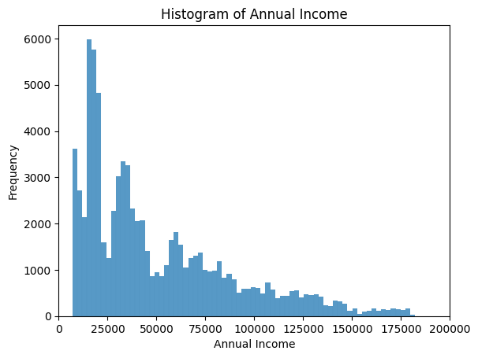

```python
# Create a histogram
sns.histplot(Clean_dataset['Annual_Income'],  edgecolor='black')
plt.xlabel('Annual Income')
plt.ylabel('Frequency')
plt.title('Histogram of Annual Income')
plt.xlim(0,200000)

# Display the histogram
plt.show()
```

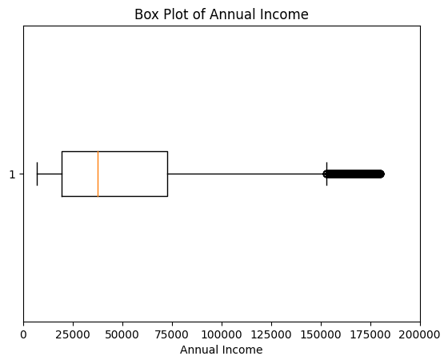

```python
# Create a box plot
plt.boxplot(Clean_dataset['Annual_Income'], vert=False)
plt.xlabel('Annual Income')
plt.title('Box Plot of Annual Income')
plt.xlim(0,200000)

# Display the box plot
plt.show()
```

**Observation**

- The histogram & Box plot for **Annual_Income**.
- Most customers have salary range between 15000 to 50000.
- In the box plot values after 150000 are presented as outliers.
- These outliers need not to be considered as Annual_Income for some customers can be really high depending on their jobs and we can not consider the removal or handling of such values.

##### 4.2.2 Monthly_Inhand_Salary Column

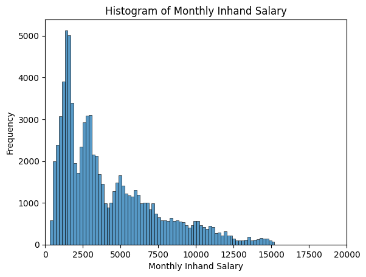

```python
# Create a histogram
sns.histplot(Clean_dataset['Monthly_Inhand_Salary'],  edgecolor='black')
plt.xlabel('Monthly Inhand Salary')
plt.ylabel('Frequency')
plt.title('Histogram of Monthly Inhand Salary')
plt.xlim(0,20000)

# Display the histogram
plt.show()
```

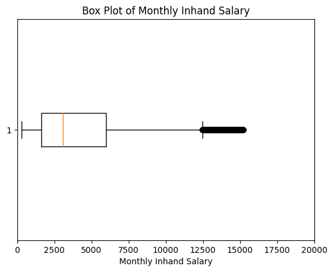

```python
# Create a box plot
plt.boxplot(Clean_dataset['Monthly_Inhand_Salary'], vert=False)
plt.xlabel('Monthly Inhand Salary')
plt.title('Box Plot of Monthly Inhand Salary')
plt.xlim(0,20000)

# Display the box plot
plt.show()
```

**Observation**

##### 4.2.3 Num_of_Loan Column

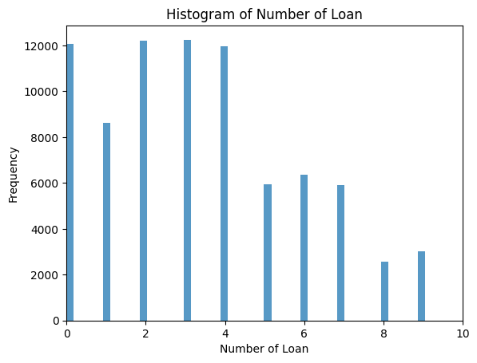

```python
# Create a histogram
sns.histplot(Clean_dataset['Num_of_Loan'],  edgecolor='black')
plt.xlabel('Number of Loan')
plt.ylabel('Frequency')
plt.title('Histogram of Number of Loan')
plt.xlim(0,10)
# Display the histogram
plt.show()
```

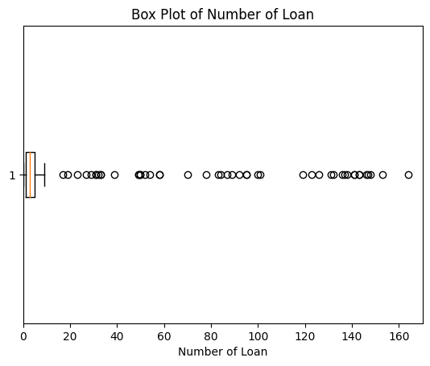

```python
# Create a box plot
plt.boxplot(Clean_dataset['Num_of_Loan'], vert=False)
plt.xlabel('Number of Loan')
plt.title('Box Plot of Number of Loan')
plt.xlim(0,170)

# Display the box plot
plt.show()
```

**Observation**

- The histogram & Box plot for **Num_of_Loan**.
- Most customers have either no loans or if they have it ranges between 2 to 4.
- There are good amount of people with number ofloans ranging from 0 to 9.
- In the box plot shows that there are some values as high as 160 and for number of loans this can not be true and thus everything beyond 9 is shown as outier.
- These outliers need to be removed from dataset by replacing them with the median value, to ensure that high end values do not influence the results.

##### 4.2.4 Delay_from_due_date Column

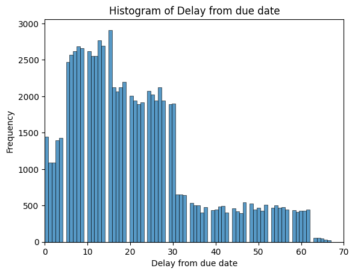

```python
# Create a histogram
sns.histplot(Clean_dataset['Delay_from_due_date'],  edgecolor='black')
plt.xlabel('Delay from due date')
plt.ylabel('Frequency')
plt.title('Histogram of Delay from due date')
plt.xlim(0,70)
# Display the histogram
plt.show()
```

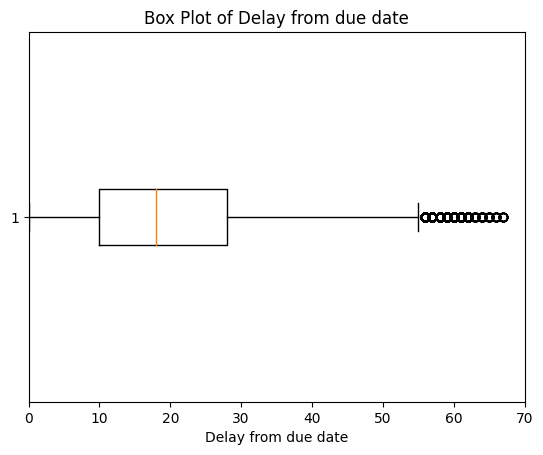

```python
# Create a box plot
plt.boxplot(Clean_dataset['Delay_from_due_date'], vert=False)
plt.xlabel('Delay from due date')
plt.title('Box Plot of Delay from due date')
plt.xlim(0,70)

# Display the box plot
plt.show()
```

**Observation**

- The histogram & Box plot for **Delay_from_due_date**.
- Most customers have delayed for 30 days.
- The box plot represents values greater than 55 as outlier.
- The values are not removed or handelled since there might be some cases with a greater due date.

##### 4.2.5 Num_of_Delayed_Payment Column

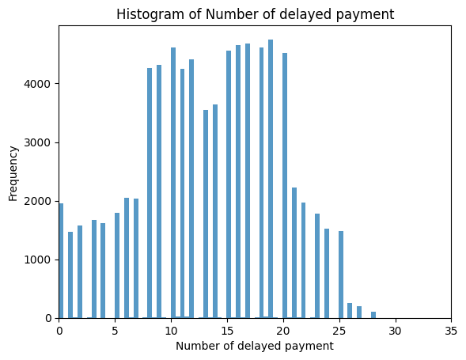

```python
# Create a histogram
sns.histplot(Clean_dataset['Num_of_Delayed_Payment'],  edgecolor='black')
plt.xlabel('Number of delayed payment')
plt.ylabel('Frequency')
plt.title('Histogram of Number of delayed payment')
plt.xlim(0,35)
# Display the histogram
plt.show()
```

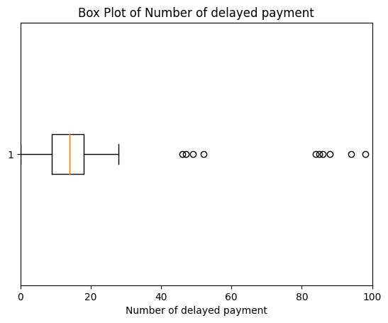

```python
# Create a box plot
plt.boxplot(Clean_dataset['Num_of_Delayed_Payment'], vert=False)
plt.xlabel('Number of delayed payment')
plt.title('Box Plot of Number of delayed payment')
plt.xlim(0,100)

# Display the box plot
plt.show()
```

**Observation**

##### 4.2.6 Outstanding_Debt Column

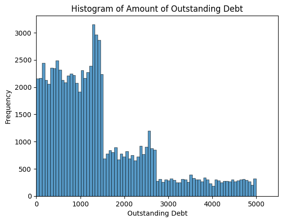

```python
# Create a histogram
sns.histplot(Clean_dataset['Outstanding_Debt'],  edgecolor='black')
plt.xlabel('Outstanding Debt')
plt.ylabel('Frequency')
plt.title('Histogram of Amount of Outstanding Debt')
plt.xlim(0,5500)
# Display the histogram
plt.show()
```

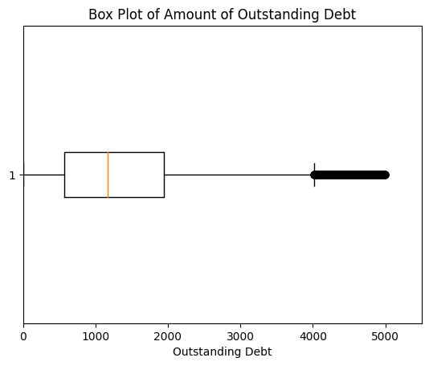

```python
# Create a box plot
plt.boxplot(Clean_dataset['Outstanding_Debt'], vert=False)
plt.xlabel('Outstanding Debt')
plt.title('Box Plot of Amount of Outstanding Debt')
plt.xlim(0,5500)

# Display the box plot
plt.show()
```

**Observation**

- The histogram & Box plot for **Outstanding Debt**.
- Most customers have 0 to 1500 outstanding debt.
- The box plot represents values greater than 4000 as outlier.
- It is possible that some customers have a high amount of outstanding debt and hence this outlier is not considered for handling.

##### 4.2.7 Credit_History_Age Column

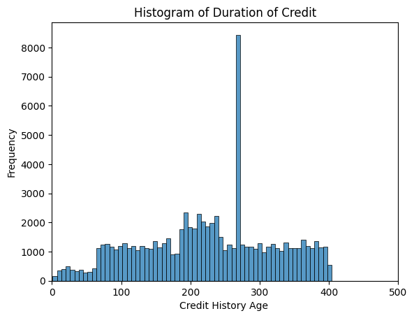

```python
# Create a histogram
sns.histplot(Clean_dataset['Credit_History_Age'],  edgecolor='black')
plt.xlabel('Credit History Age ')
plt.ylabel('Frequency')
plt.title('Histogram of Duration of Credit')
plt.xlim(0,500)
# Display the histogram
plt.show()
```

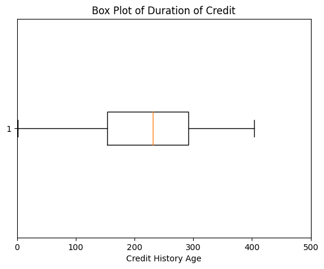

```python
# Create a box plot
plt.boxplot(Clean_dataset['Credit_History_Age'], vert=False)
plt.xlabel('Credit History Age')
plt.title('Box Plot of Duration of Credit')
plt.xlim(0,500)

# Display the box plot
plt.show()
```

**Observation**

- The histogram & Box plot for **Credit History Age**.
- As we converted values like 2 yrs 4 months to 28 (thats total months)
- The highest credit age which most customers have is around 267.
- The range of months ends at 400 and the box plot does not consider any value as outlier.

##### 4.2.8 Total_EMI_per_month Column

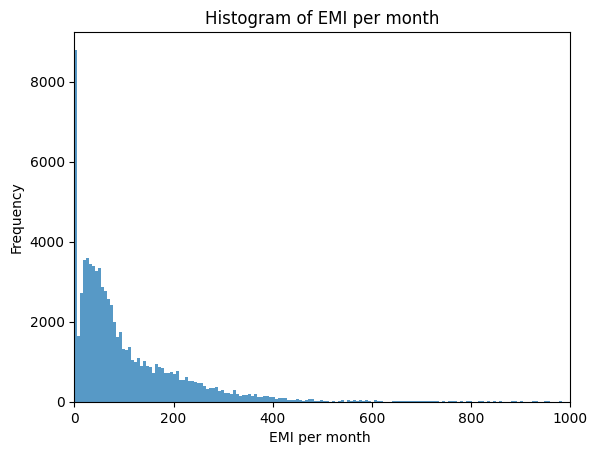

```python
# Create a histogram
sns.histplot(Clean_dataset['Total_EMI_per_month'],  edgecolor='black')
plt.xlabel('EMI per month ')
plt.ylabel('Frequency')
plt.title('Histogram of EMI per month')
plt.xlim(0,1000)
# Display the histogram
plt.show()
```

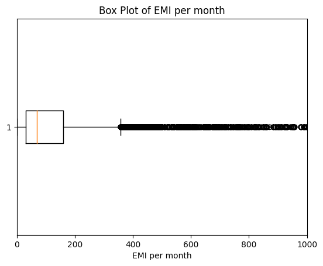

```python
# Create a box plot
plt.boxplot(Clean_dataset['Total_EMI_per_month'], vert=False)
plt.xlabel('EMI per month')
plt.title('Box Plot of EMI per month')
plt.xlim(0,1000)

# Display the box plot
plt.show()
```

**Observation**

- The histogram & Box plot for **EMI per month**.
- Most customers have 0 to 400 as emi per month.
- There are some customers which has emi range greater than this but are less in number.
- There might be customers with high emi values if there loan amounts are high and so we cannot consider it as outlier.

##### 4.2.9 Monthly_Balance Column

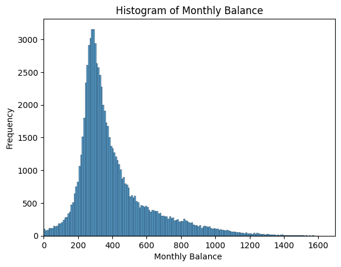

```python
# Create a histogram
sns.histplot(Clean_dataset['Monthly_Balance'],  edgecolor='black')
plt.xlabel('Monthly Balance ')
plt.ylabel('Frequency')
plt.title('Histogram of Monthly Balance')
plt.xlim(0,1700)
# Display the histogram
plt.show()
```

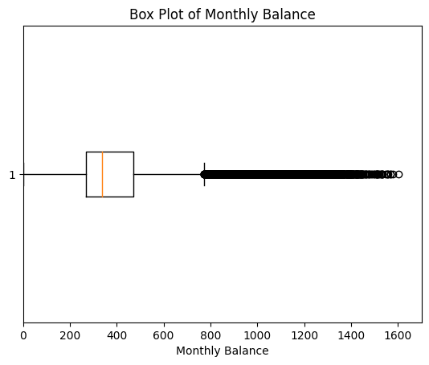

```python
# Create a box plot
plt.boxplot(Clean_dataset['Monthly_Balance'], vert=False)
plt.xlabel('Monthly Balance')
plt.title('Box Plot of Monthly Balance')
plt.xlim(0,1700)

# Display the box plot
plt.show()
```

**Observation**

##### 4.2.10 Occupation Column

```
Count for each type :::
Lawyer           5834
Engineer         5606
Architect        5582
Accountant       5506
Mechanic         5480
Scientist        5454
Teacher          5446
Developer        5429
Entrepreneur     5419
Media_Manager    5401
Journalist       5319
Doctor           5316
Manager          5215
Musician         5185
Writer           5092
Name: Occupation, dtype: int64
----------------------------
----------------------------
```

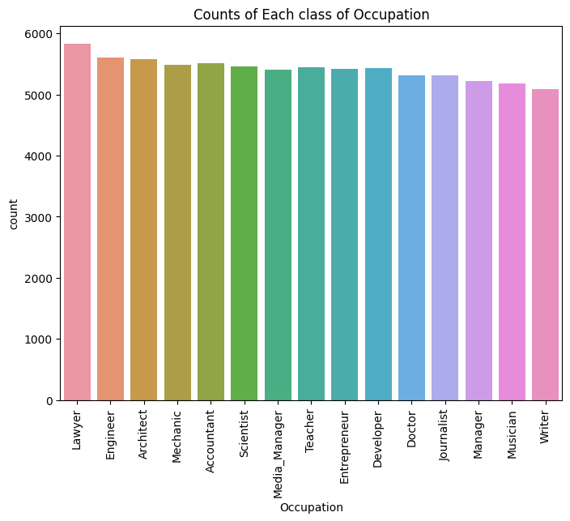

```python
print("Count for each type :::")
print(Clean_dataset['Occupation'].value_counts())
print("----------------------------")
print("----------------------------")


plt.figure(figsize = (8,6))
ax = sns.countplot(x=Clean_dataset['Occupation'], order= ['Lawyer','Engineer','Architect','Mechanic','Accountant','Scientist','Media_Manager','Teacher','Entrepreneur','Developer','Doctor','Journalist','Manager','Musician','Writer'])
ax.set_xticklabels(ax.get_xticklabels(), rotation=90)
plt.title("Counts of Each class of Occupation")
plt.show()
```

**Observation**

- Maximum number of customers are Lawyer.
- Least popular occupation among customers is Writer.

##### 4.2.11 Payment_of_Min_Amount Column

```
Count for each type :::
Yes    48320
No     32964
Name: Payment_of_Min_Amount, dtype: int64
----------------------------
----------------------------
```

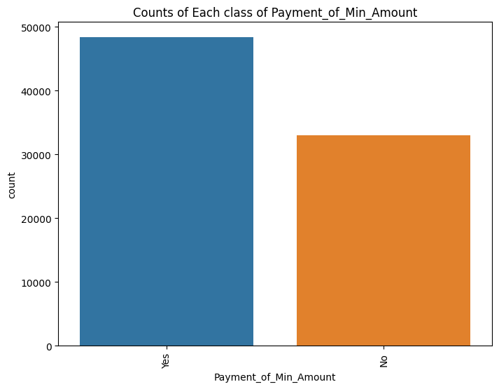

```python
print("Count for each type :::")
print(Clean_dataset['Payment_of_Min_Amount'].value_counts())
print("----------------------------")
print("----------------------------")


plt.figure(figsize = (8,6))
ax = sns.countplot(x=Clean_dataset['Payment_of_Min_Amount'], order= ['Yes','No'])
ax.set_xticklabels(ax.get_xticklabels(), rotation=90)
plt.title("Counts of Each class of Payment_of_Min_Amount")
plt.show()
```

**Observation**

- There are very high number of payments of minimum amount.

##### 4.2.12 Payment_Behaviour Column

```
Count for each type :::
Low_spent_Small_value_payments      22489
High_spent_Medium_value_payments    15379
Low_spent_Medium_value_payments     12132
High_spent_Large_value_payments     12102
High_spent_Small_value_payments      9961
Low_spent_Large_value_payments       9221
Name: Payment_Behaviour, dtype: int64
----------------------------
----------------------------
```

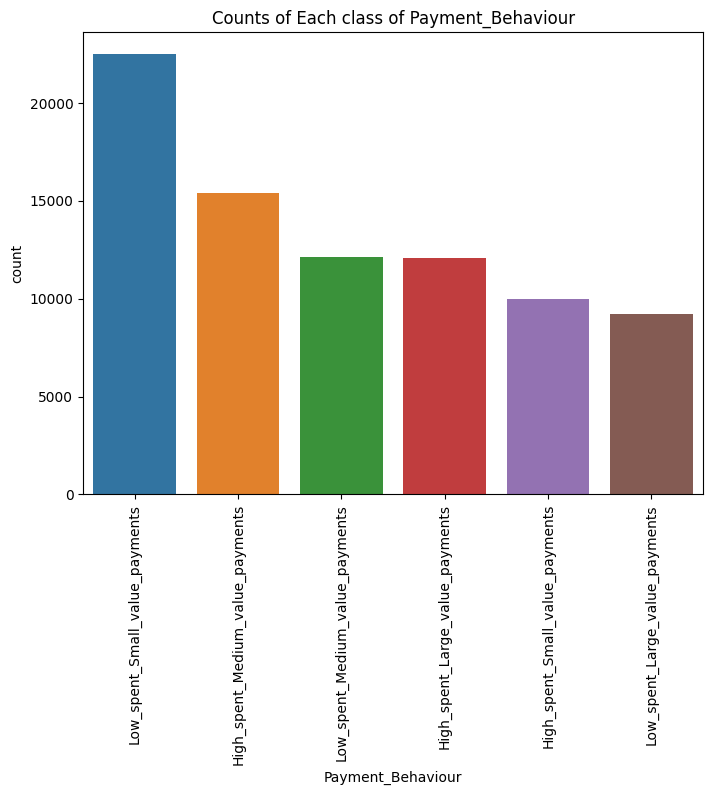

```python
print("Count for each type :::")
print(Clean_dataset['Payment_Behaviour'].value_counts())
print("----------------------------")
print("----------------------------")


plt.figure(figsize = (8,6))
ax = sns.countplot(x=Clean_dataset['Payment_Behaviour'], order= ['Low_spent_Small_value_payments','High_spent_Medium_value_payments','Low_spent_Medium_value_payments','High_spent_Large_value_payments','High_spent_Small_value_payments','Low_spent_Large_value_payments'])
ax.set_xticklabels(ax.get_xticklabels(), rotation=90)
plt.title("Counts of Each class of Payment_Behaviour")
plt.show()
```

**Observation**

- There are very high number of low spent small value payments in **Payment_Behaviour**.

##### 4.2.13 Credit_Score Column

```
Count for each type :::
Standard    43401
Poor        23532
Good        14351
Name: Credit_Score, dtype: int64
----------------------------
----------------------------
```

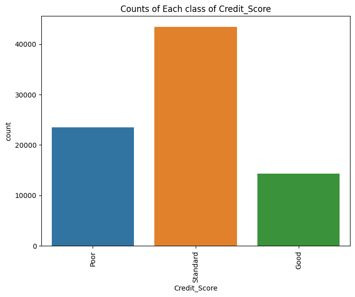

```python
print("Count for each type :::")
print(Clean_dataset['Credit_Score'].value_counts())
print("----------------------------")
print("----------------------------")


plt.figure(figsize = (8,6))
ax = sns.countplot(x=Clean_dataset['Credit_Score'], order= ['Poor','Standard','Good'])
ax.set_xticklabels(ax.get_xticklabels(), rotation=90)
plt.title("Counts of Each class of Credit_Score")
plt.show()
```

**Observation**

- The target variable **Credit_Score** has maximum values as Standard.
- The target variable is not having balanced values and so balancing needs to be applied for the values of Credit_Score.

#### 4.3 Multivariant Analysis

- Considered seening relation of different variables with target variable using box plot.
- Heatmap is used to see the correlation between various variables.

##### 4.3.1 Target Variable(Credit_Score ) with Annual_Income Column

```
(0.0, 200000.0)
```

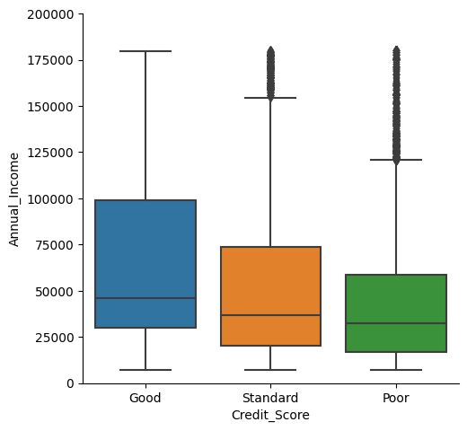

```python
sns.catplot(data=Clean_dataset, x="Credit_Score", y="Annual_Income", kind="box")
plt.ylim(0,200000)
```

**Observation**

- The understanding from this box plot can be made that there are a lot of people with high annual income but they still have poor credit score.

##### 4.3.2 Target Variable(Credit_Score ) with Monthly_Inhand_Salary Column

```
(0.0, 17500.0)
```

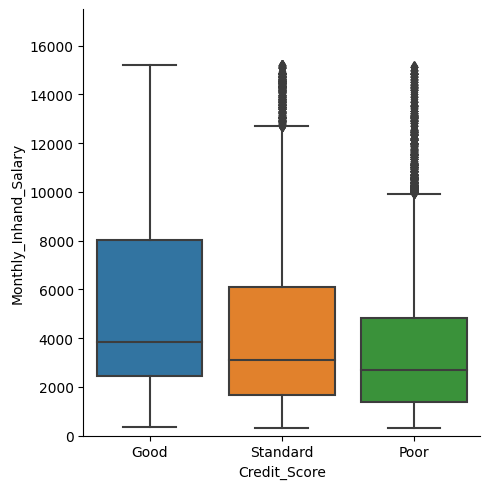

```python
sns.catplot(data=Clean_dataset, x="Credit_Score", y="Monthly_Inhand_Salary", kind="box")
plt.ylim(0,17500)
```

**Observation**

- The understanding from this box plot can be made that there are a lot of people with high monthly inhand income but they still have poor credit score.

##### 4.3.3 Target Variable(Credit_Score ) with Num_of_Loan Column

```
(0.0, 50.0)
```

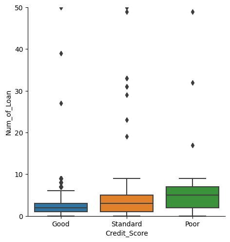

```python
sns.catplot(data=Clean_dataset, x="Credit_Score", y="Num_of_Loan", kind="box")
plt.ylim(0,50)
```

**Observation**

- The understanding from this box plot that median is highest for poor credit score with respect to number of loans and there are a lot of outliers.

##### 4.3.4 Target Variable(Credit_Score ) with Delay_from_due_date Column

```
(0.0, 100.0)
```

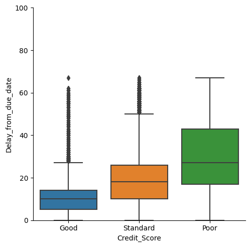

```python
sns.catplot(data=Clean_dataset, x="Credit_Score", y="Delay_from_due_date", kind="box")
plt.ylim(0,100)
```

**Observation**

- The understanding from this box plot that the median for good credit score with respect to delay from due date is low and there are a lot of outliers in this group.

##### 4.3.5 Target Variable(Credit_Score ) with Num_of_Delayed_Payment Column

```
(0.0, 100.0)
```

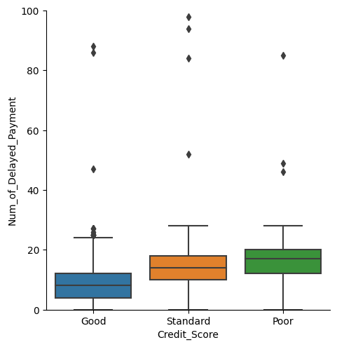

```python
sns.catplot(data=Clean_dataset, x="Credit_Score", y="Num_of_Delayed_Payment", kind="box")
plt.ylim(0,100)
```

**Observation**

- The understanding from this box plot that the median for good credit score with respect to number of delay payment is low while for poor is high highlighting that as the number of delayed payment increase the credit score is affected.

##### 4.3.6 Target Variable(Credit_Score ) with Outstanding_Debt Column

```
(0.0, 6000.0)
```

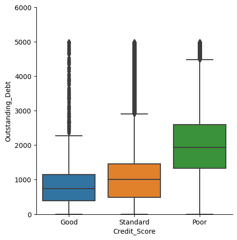

```python
sns.catplot(data=Clean_dataset, x="Credit_Score", y="Outstanding_Debt", kind="box")
plt.ylim(0,6000)
```

**Observation**

- The understanding from this box plot that the median for good credit score with respect to number of outstanding debt is low while for poor is high highlighting that as the number of outstanding debt increase the credit score is affected.

##### 4.3.7 Target Variable(Credit_Score ) with Credit_History_Age Column

```
(0.0, 600.0)
```

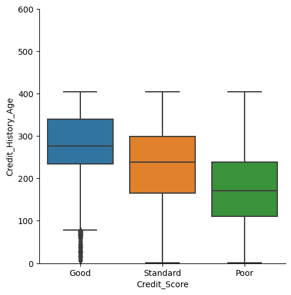

```python
sns.catplot(data=Clean_dataset, x="Credit_Score", y="Credit_History_Age", kind="box")
plt.ylim(0,600)
```

**Observation**

- A good credit score can be maintained for a loan of longer duration.

##### 4.3.8 Target Variable(Credit_Score ) with Total_EMI_per_month Column

```
(0.0, 1000.0)
```

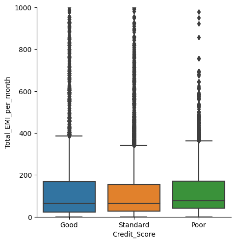

```python
sns.catplot(data=Clean_dataset, x="Credit_Score", y="Total_EMI_per_month", kind="box")
plt.ylim(0,1000)
```

**Observation**

- The median for all three creedit score is almost at same level with respect to the EMI per month.

##### 4.3.9 Target Variable(Credit_Score ) with Monthly_Balance Column

```
(0.0, 2000.0)
```

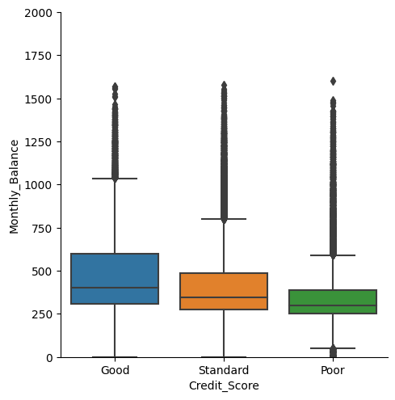

```python
sns.catplot(data=Clean_dataset, x="Credit_Score", y="Monthly_Balance", kind="box")
plt.ylim(0,2000)
```

**Observation**

- The highest median monthly balance is for good credit score but there are lots of people with poor credit score by have high monthly balance and thus can be defaulters.

##### 4.3.10 Target Variable(Credit_Score ) with Occupation Column

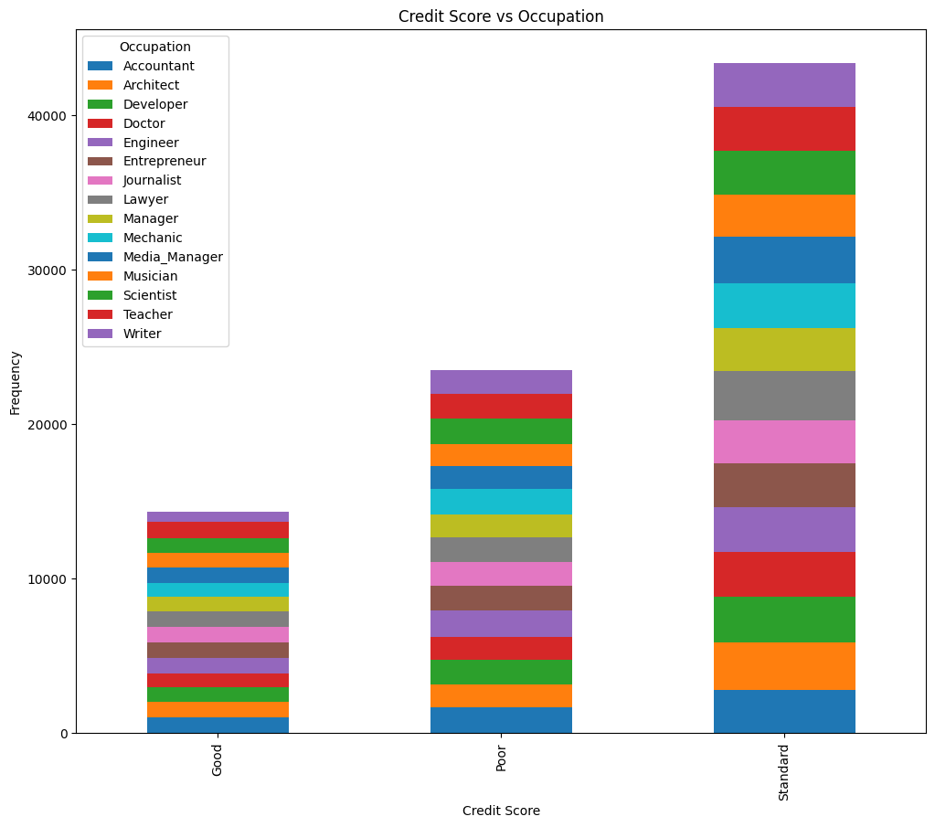

```python
# Create the contingency table
table = pd.crosstab(Clean_dataset['Credit_Score'], Clean_dataset['Occupation'])

# Set the figure size (width, height) in inches
fig, ax = plt.subplots(figsize=(12, 10))

# Plot the table
table.plot(kind='bar', stacked=True ,  ax=ax)
plt.title('Credit Score vs Occupation')
plt.xlabel('Credit Score')
plt.ylabel('Frequency')
plt.show()
```

**Observation**

- The graph shows the distribution of various occupations in the different credit score categories.
- Distribution of all occupation looks equal in case of standard credit score.